# WeeklyReport20171129

Cheng Fan

November 29, 2017

## 1 Web Scrapying

Last time we discussed about getting more variables from websides.

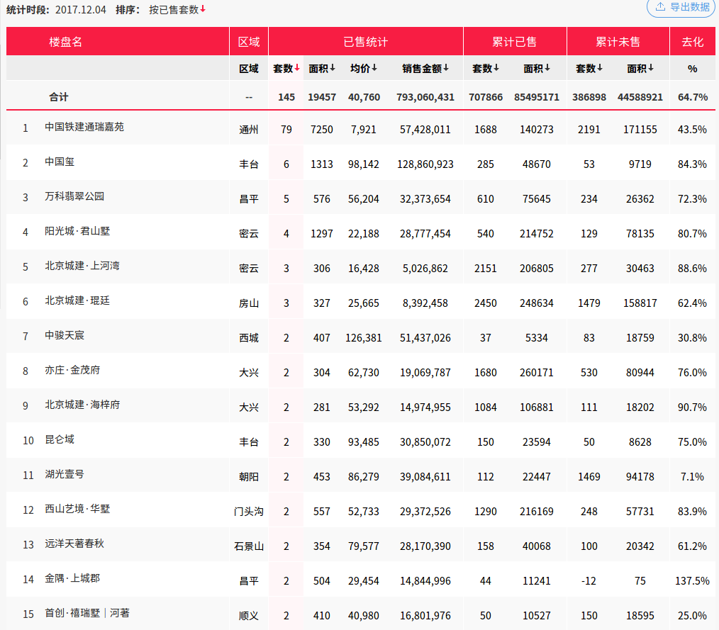

EI datahouse

Let’s take a look at the textdata first.

```r
textdata <- readLines("~/Documents/neteases2016-01.txt")
head(textdata, 5)
```

```
## [1] "2016.01.01|1|首城汇景湾||平谷|9|996|12,630|12,579,095|1466|146008|212|64286|87.4%|均价：17000元/㎡|平谷- 马坊[六环以外]北京市平谷区马坊镇京平高速密三出口南200米路西（北师大附中对面）|公交站梨羊路口178米梨羊224米|地铁站暂无数据饮食鸿海泰260米|银行大孙各庄邮政储蓄所2973米|医院马坊医院998米|学校大孙各庄镇椒园完小2694|米"
## [2] "2016.01.01|2|密云华润橡树湾||密云|7|658|18,634|12,261,374|1134|125751|207|27721|84.6%||密云- 密云[六环以外]密云县密云镇滨河路水源路交叉口东南角|公交站密云体育局221米太阳家园600米|地铁站暂无数据|银行中国农业银行(密云阳光街支行)1095米|医院怀光卫生室669米|超市龙凤华娜商店651米|学校小天使幼儿园(顺密旧路)1038米"
## [3] "2016.01.01|3|东亚·印象台湖||通州|6|419|24,340|10,198,501|1540|103598|364|24848|80.9%下载失败"
## [4] "2016.01.01|4|冠城大通百旺府||海淀|5|720|40,314|29,026,184|1212|163569|187|27017|86.6%|说明最低价：1000万元/套 板块均价70253元/㎡|海淀- 上清[五至六环]海淀区北青路北航天城西(永丰产业基地东)|公交站辛店134米永丰嘉园346米|地铁站暂无数据|学校北京市海淀区永丰中心小学1413米学校金色童年艺术双语幼儿园1381米学校益铭双语艺术幼儿园1381米学校北京市海淀区丰联小学1150|||米"
## [5] "2016.01.01|5|顶秀美泉小镇||怀柔|4|462|23,224|10,729,419|1725|187297|1037|75272|62.5%|均价：35000元/㎡|怀柔- 怀柔[六环以外]怀柔区雁栖湖范各庄村|公交站顶秀美泉小镇373米顶秀443米|地铁站暂无数据|医院雁栖医院1795米|学校怀柔二十一世纪幼儿园（小镇...100||米"
```

## 2 Data Cleaning

We have to do some data cleaning. The first thing is to deal with the text. The last five varialbes are about bus station, subway station, bank, hospital, school. For the first three variables (bus station, subway station, bank), we chose the distance to be the value. For hospital and school, we want to make them to be dummy variables.

Here are the list of the first-class hospitals and all the primary schools and middle high schools.

```r
hospital <- read.csv("~/Documents/北京市三甲医院.csv", header = TRUE, skip = 1)
hospital
```

```
##        地区                           名称
## 1    东城区                   北京协和医院
## 2                             北京地坛医院
## 3                           北京市公安医院
## 4                           北京军区总医院
## 5                           北京妇幼保健院
## 6                 北京中医药大学东直门医院
## 7                           卫生部北京医院
## 8                             北京中医医院
## 9                             北京同仁医院
## 10   西城区               北京大学人民医院
## 11                        北京协和医院西院
## 12                        阜外心血管病医院
## 13                        北京大学第一医院
## 14            首都医科大学附属北京儿童医院
```

[output cut: 290 more lines]

```r
school <- read.csv("~/Documents/中学小学排名.csv", header = TRUE)
head(school, 20)
```

```
##    排名   区域           中学 最低录取分
## 1     1   海淀       人大附中        564
## 2     2   西城       北京四中        563
## 3     3   西城 北师大实验中学        560
## 4     4   丰台       北京12中        560
## 5     5   海淀       清华附中        559
## 6     6   东城        北京2中        559
## 7     7   海淀        101中学        558
## 8     8   海淀       十一学校        558
## 9     9   西城        北京8中        556
## 10   10   西城   北师大二附中        555
## 11   11   西城 实验二龙路中学        555
## 12   12   海淀     首师大附中        554
## 13   13   海淀       北大附中        554
## 14   14   朝阳       北京80中        554
## 15   15   东城        北京5中        554
## 16   16   西城     北师大附中        553
## 17   17   东城        171中学        553
## 18   18   通州       潞河中学        553
## 19   19 石景山       京源学校        552
## 20   20   东城     广渠门中学        552
```

According to the two lists, we can get two dummy variables from the textdata.

After dealing with the last five colomes, we can get five more variables.

```r
cleandata <- readLines("~/Documents/house_cleandata.txt")
head(cleandata)
```

```
## [1] "|2017.11.01|1|城建万科城||延庆|63|4988|25,378|126,583,720|575|48348|359|29210|61.6%|说明2.6万-2.7万元/㎡|316|暂无|0|434|0"
## [2] "|2017.11.01|2|亦庄·金茂府||大兴|7|1049|54,066|56,714,721|1594|247022|616|94093|72.1%|说明最低价：880万元/套 板块均价60411元/㎡|695|暂无|暂无|暂无|0"
## [3] "|2017.11.01|3|翡翠四季||通州|7|892|55,443|49,454,807|718|66719|32|3593|95.7%|说明最低价：900万元/套 板块均价62794元/㎡|540|1805|暂无|暂无|0"
## [4] "|2017.11.01|4|华润未来城市||昌平|4|373|62,697|23,385,890|218|24415|120|15883|64.5%|说明5.9万-6.1万元/㎡|442|暂无|暂无|暂无|0"
## [5] "|2017.11.01|5|北京城建·海梓府||大兴|3|271|48,454|13,130,923|1036|101683|111|18202|90.3%|说明530-780万元/套 板块均价60411元/㎡|570|5500|暂无|暂无|0"
## [6] "|2017.11.01|6|阳光城·京兆府||通州|3|347|56,406|19,572,891|131|16424|277|34706|32.1%|说明最低价：1200万元/套 板块均价62794元/㎡|暂无|暂无|暂无|暂无|暂无"
```

# Problems

There are still some problems left to be done.

1. The whole web scraping process is still going on the server. We have to deal with a huge dataset.
2. The names of the house need to be replaced by their longitude and latitude (according to the address).
3. The comma between the numbers should be deleted.
4. How to tell the price per unit if there is only a price for an apartment?
5. Can I just keep the NA?

## 3 Fit the surface model